# 1 *Season BOE: A Simple COVID-19 Back-of-the-Envelope Model*

## 1.1 *Introduction*

- *Given that SARS-CoV2 immunity as reached ‘equilibrium’, can we model viral spread in a very simplified way?*
- *high viral attack rate (likely above 50% per year) relative to typical speed of waning (substantial waning within 1/2 year)*
- *immunity has reached an equilibrium: majority of individuals in EU/EEA have had multiple exposures and vaccines, and for impact of infection on transmission the immunity history does not matter*
- *Thus, infection impact on population immunity can be modelled similarity for 22/23 as for 23/24*

*absence of NPIs, and less prevalence-elastic behaviour -> Rt mostly impacted by immunity, seasonality, variants

*by accounting for immunity (and variants) can we estimate seasonality?

## 1.2 *Method assumptions in very brief*

- *Infection-intensity indicator is proportional to the true infection incidence (clearly NOT true with reported cases)*
- *Viral transmission is only driven through seasonality, immunity accumulation and waning (and new variants)*
- *Thus, at a similar time of the year, a similar Rt value implies a similar level of prevailing population-immunity (assuming no impact of variants)*
- *For example we could say: in Nov 2022 and in Nov 2023 when Rt was close to 1, population-immunity was nearly the same*
- *Immunity waning occurs in a relatively simple way ( 100%-immunity-compartment -> X%-immunity-compartment -> susceptible with exponential flow )*
- *Parametric assumptions*
- *Serial interval (si)=3.6 days*
- *R0 (r0) = 6*
- *Yearly infection attack-rate (ar): 60%*
- *Reduction in susceptibility through infection (re): 90%*

## 1.3 *Conceptual model walk through*

```r
knitr::opts_chunk$set(warning = FALSE, message = FALSE)
library(here)
# set R up
source("../setup.R")
```

```
## Run time setup01.R : 7.66 sec
```

```r
source("settings.R")
source("functions_specific.R")
source("checks.R")
```

```r
compute_Rt_without_immunity = function( par,
                                        # ability to fix parameters
                                        wane_imm_fract_weekly_1_log=NA,
                                        Imm_2_partial=NA,
                                        wane_imm_fract_weekly_2_log=NA,
                                        #
                                        df_Rt_value_pop,
                                        for_optim=F,
                                        p,
                                        days_to_week,
                                        sim_o=NA) {
  # df_Rt_value_pop must be daily
  # we apply a chunking-of-days technique to speed up optim etc
  simulate = !is.na(sim_o)[1] # logical to determine whether or not to forward simulate
  ## recasting parameters (needed due to optim use)
  p$ar_and_re = exp(par[1])
  wane_imm_fract_weekly_1_logit = wane_imm_fract_weekly_1_log
  if (is.na(wane_imm_fract_weekly_1_log)) wane_imm_fract_weekly_1_logit = par[2]
  Imm_2_partial_logit = Imm_2_partial
  if (is.na(Imm_2_partial)) Imm_2_partial_logit = par[3]
  wane_imm_fract_weekly_2_logit = wane_imm_fract_weekly_2_log
  if (is.na(wane_imm_fract_weekly_2_log)) wane_imm_fract_weekly_2_logit = par[4]


  # waning compartments could be further extended
  # wane_imm_fract_weekly_3_logit = par[4]
  # Imm_3_partial
  df_all  = df_Rt_value_pop
  df_all = df_all[1:days_to_week$n_full_weeks,]
  # weeks and days
  nweeks = days_to_week$nweeks
  weekly_daygroups_t = days_to_week$weekly_daygroups_t
  weekly_daygroups_tlast = days_to_week$weekly_daygroups_tlast

  ## transformations
  Imm_2_partial = inv_logit(Imm_2_partial_logit)
  wane_imm_fract_weekly_1 = inv_logit(wane_imm_fract_weekly_1_logit) # scale daily/weekly
  wane_imm_fract_weekly_2 = inv_logit(wane_imm_fract_weekly_2_logit) # scale daily/weekly
  # wane_imm_fract_weekly_3 = exp(wane_imm_fract_weekly_3_log)

  ## country loop
  # for each location, simulate immunity and update target based on conditions
  location_v = unique(df_all$location_name)
  df_save = list()
  target = 0 # initiate target for optimisation
  min_target = 0 # initiate minimum target for optimisation
  for (i in location_v) { # i = location_v[1]
    df_i = df_all %>% filter(location_name==i)

    #### value: infection intensity
    if (!simulate) {
      # normalise infection intensity (so that infection attack rate is 1% each year)
      laste_year_ii = mlast(df_i$value,n=365)/mlast(df_i$population,n=365)
      df_i$value = df_i$value * ( 0.01/sum(  laste_year_ii  )  )
    }
    if (simulate) {
      df_i$value = 0; df_i$value[ weekly_daygroups_tlast[[1]][1] ] = sim_o$inf_ini
    }

    #### Imm_X: the different immunity compartments
    df_i$Imm_1 = NA;
    df_i$Imm_2 = NA;
    if (!simulate) {
      # initial Rt and immunity
      Rt_ini = mean(df_i$Rt[1:p$Rt_for_ini_est]) # avoiding impact of noise in Rt
      Imm_ini = (p$R0 - Rt_ini)/p$R0 # back-calculating immunity from Rt and R0
      # assuming that all immunity is recent (thus all into first immunity compartment)
      df_i$Imm_1[weekly_daygroups_tlast[[1]]] = Imm_ini # full immunity
      df_i$Imm_2[weekly_daygroups_tlast[[1]]] = 0 # partial immunity
    }
    if (simulate) {
      # initial immunity
      df_i$Imm_1[weekly_daygroups_tlast[[1]]] = sim_o$Imm_1_ini
      df_i$Imm_2[weekly_daygroups_tlast[[1]]] = sim_o$Imm_2_ini
    }
    # build immunity from the immunity compartments
    df_i$Imm = NA;
    df_i$Imm[weekly_daygroups_tlast[[1]]] = df_i$Imm_1[weekly_daygroups_tlast[[1]]] + df_i$Imm_2[weekly_daygroups_tlast[[1]]]*Imm_2_partial # immunity combined

    #### waning_X: waning from the different immunity compartments
    # initiate waning
    df_i$waning_1 = NA; df_i$waning_1[weekly_daygroups_tlast[[1]]] = 0
    df_i$waning_2 = NA; df_i$waning_2[weekly_daygroups_tlast[[1]]] = 0
    df_i$new_Imm = NA; df_i$new_Imm[weekly_daygroups_tlast[[1]]] = 0

    #### Rt_without_immunity and Rt with immmunity
    if (!simulate){
      # compute Rt without immunity
      df_i$Rt_without_immunity = NA;
      df_i$Rt_without_immunity[weekly_daygroups_tlast[[1]]] = df_i$Rt[weekly_daygroups_tlast[[1]]] * 1/(1-Imm_ini)
    }
    if (simulate) {
      # Rt without immunity exist, compute Rt effective
      df_i$Rt_eff = NA
      df_i$Rt_without_immunity = df_i$Rt_seasonal
      df_i$Rt_eff[weekly_daygroups_tlast[[1]]] =
        df_i$Rt_without_immunity[weekly_daygroups_tlast[[1]]] * (1-df_i$Imm[weekly_daygroups_tlast[[1]]])
    }

    #### sX: different scenarios
    ## counter-factuals/scenarios/helpers
    df_i$s1 = NA; df_i$s1[weekly_daygroups_tlast[[1]]] = 1
    df_i$s1_1 = NA; df_i$s1_1[weekly_daygroups_tlast[[1]]] = 1
    df_i$s1_2 = NA; df_i$s1_2[weekly_daygroups_tlast[[1]]] = 0
    #
    df_i$s2 = NA; df_i$s2[weekly_daygroups_tlast[[1]]] = 1
    #
    df_i$s3 = NA; df_i$s3[weekly_daygroups_tlast[[1]]] = df_i$s1[weekly_daygroups_tlast[[1]]]*df_i$Imm[weekly_daygroups_tlast[[1]]]

    # time loop (through chunks of days of a given location)
    for (t in 1:nweeks ) { # t = 1
      # deal with weekly to daily
      t_days  = weekly_daygroups_t[[t]]
      tlast_days  = weekly_daygroups_tlast[[t]]
      # simlate infections (value) daily stemming from last week
      if (simulate) {
        # handle daily growth simulation 1 day-chunk at a time
        for (chunk_day_i in 1:length(tlast_days) ){ # chunk_day_i = 1
          whichday = tlast_days[chunk_day_i]
          current_infection = df_i$value[whichday]
          current_Rt = df_i$Rt_eff[whichday]
          current_offspring = current_infection * current_Rt

          si_v_along = c(1:length(sim_o$si_distribution))

          ## add offspring incident infections back into value
          distributed_offspring = current_offspring * sim_o$si_distribution
          # truncate if offspring goes beyond
          n_too_long = ( whichday+mlast(si_v_along) ) - days_to_week$n_full_weeks
          trunk_v = c( 1:( length(whichday+si_v_along)-max(n_too_long,0) ) )
          # add the offspring
          df_i$value[(whichday+si_v_along)[trunk_v]] = df_i$value[(whichday+si_v_along)[trunk_v]] +
            distributed_offspring[trunk_v]
        } # df_i$value[1: (whichday+mlast(si_v_along)) ] %>% plot()
      }

      # immunity waning (allowing different immunity compartments)
      # Imm_1 is the full immunity compartment
      # Imm_2 3, ... are partial immunity compartments
      waning_1 = df_i$Imm_1[tlast_days[1]]*wane_imm_fract_weekly_1
      waning_2 = df_i$Imm_2[tlast_days[1]]*wane_imm_fract_weekly_2
      df_i$waning_1[t_days] = waning_1/7 # distribute over days
      df_i$waning_2[t_days] = waning_2/7 # distribute over days
      # accumulation of new immunity (proportional to: value = "infection intensity",dark_factor,NE)
      new_infections = sum(df_i$value[tlast_days]/df_i$population[tlast_days])
      new_Imm = new_infections * p$ar_and_re
      df_i$new_Imm[t_days] = new_Imm/7 # distribute over days
      # new infections also come from partly susceptible Imm compartments
      full_susc = 1 - ( df_i$Imm_1[tlast_days[1]] + df_i$Imm_2[tlast_days[1]] )
      if (full_susc<0) print("warning0")
      new_Imm_from_Imm_2 = df_i$Imm_2[tlast_days[1]]*Imm_2_partial /
        ( df_i$Imm_2[tlast_days[1]]*Imm_2_partial + full_susc*1 )
      # apply changes to Immunity compartments
      df_i$Imm_1[t_days] = df_i$Imm_1[tlast_days[1]] - waning_1 + new_Imm
      df_i$Imm_2[t_days] = df_i$Imm_2[tlast_days[1]] - waning_2 + waning_1 - new_Imm_from_Imm_2*new_Imm
      if (any(df_i$Imm_1[t_days]<0)) print("warning1")
      if (any(df_i$Imm_2[t_days]<0)) {print("warning2");}
      # recompute combined "effective" immunity
      df_i$Imm[t_days] = df_i$Imm_1[t_days] + df_i$Imm_2[t_days]*Imm_2_partial
      # compute new Rt without immunity (Rt AS IF immunity would have vanished)
      if (!simulate) df_i$Rt_without_immunity[t_days] = df_i$Rt[t_days] * 1/(1-df_i$Imm[t_days])
      if ( simulate) df_i$Rt_eff[t_days] = df_i$Rt_without_immunity[t_days] * (1-df_i$Imm[t_days])

      ## scenarios
      # 1: just waning shape
      waning_s1_1 = df_i$s1_1[tlast_days[1]]*wane_imm_fract_weekly_1
      waning_s1_2 = df_i$s1_2[tlast_days[1]]*wane_imm_fract_weekly_2
      df_i$s1_1[t_days] = df_i$s1_1[tlast_days] - waning_s1_1
      df_i$s1_2[t_days] = df_i$s1_2[tlast_days] - waning_s1_2 + waning_s1_1
      df_i$s1[t_days] = df_i$s1_1[t_days] + df_i$s1_2[t_days]*Imm_2_partial
      # 2: just accounting for new immunity
      new_week_eff_immunity = sum(df_i$value[tlast_days]/df_i$population[tlast_days]) * p$ar_and_re
      new_week_Rt_modifier = 1 - new_week_eff_immunity
      new_week_Rt_modifier_inv = 1 / new_week_Rt_modifier
      df_i$s2[t_days] = df_i$s2[tlast_days] * new_week_Rt_modifier_inv
      # 3: just accounting for immunity from the start
      df_i$s3[t_days] = df_i$s1[t_days]*df_i$Imm[1]
    }

    if (!simulate){
      ## "target" allows multiple constraints
      # regularize: immunity last year ~ immunity 1 year later
      Imm_diff = df_i$Imm[df_i$Rt_at_one==1] - df_i$Imm[df_i$Rt_at_one==2]
      target_Imm_diff = -dnorm(x=Imm_diff,mean = 0,sd=0.05, log = T)
      target_Imm_diff_min = -dnorm(x=0,mean = 0,sd=0.05, log = T)
      # regularize: R0 based on Rt and R0
      # note: Rt_without immunity can exceed R0, since Rt and Immunity beyong the initial condition don't know about each other
      max_Rt_without_immunity = max(df_i$Rt_without_immunity,na.rm=T)
      target_Rt_without_immunity = -dnorm(x=max_Rt_without_immunity,mean = p$R0,sd=1, log = T)
      target_Rt_without_immunity_min = -dnorm(x=p$R0,mean = p$R0,sd=1, log = T)
      # regularize; effective waning

      # could also regularize; max immunity in the population

      target = target + target_Imm_diff + target_Rt_without_immunity
      min_target = min_target = target_Imm_diff_min + target_Rt_without_immunity_min # -1.157855
    }

    # print(paste("min target:",min_target %>% round(2)))
    # print(paste("Max new_Imm",max(df_i$new_Imm) %>% round(3),i))
    # print(paste("Average waning",mean(df_i$waning) %>% round(3),i))
    df_save[[i]] = df_i
  }
  # pack it all up
  df_return = bind_rows(df_save) %>%
    mutate(target=target,
           min_target=min_target)

  # return depending on where the function is used
  if (for_optim==T) return(target)
  if (for_optim==F) return(df_return)
}
```

### 1.3.1 *“Infection intensity” data*

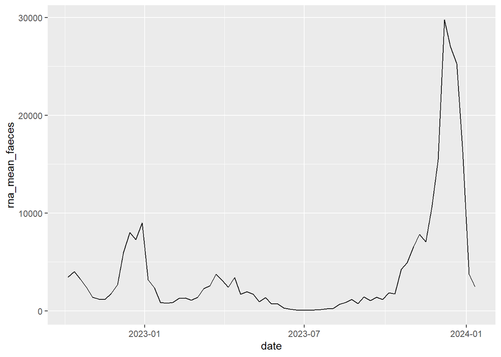

```r
# date, value, location
path_data="../../../Big input data/2024-01-17_dk_wastewater_data.csv"
x=read_csv(path_data)
x %>% filter(date>"2022-10-01",date<"2024-02-03") %>% ggplot(aes(date,rna_mean_faeces)) + geom_line() #
```

```r
# ready for main
df_ii_weekly = x %>% select(date=date,
                            value=rna_mean_faeces) %>%
  mutate(location="DK")
no_duplication_no_gaps_right_order(df_ii_weekly)
```

```
## df_ii has NO duplications, has evenly spaced gaps, is arranged correctly, without NAs in value :-)
```

```r
df_ii = weekly_make_daily(df_ii_weekly)
df_ii= df_ii %>% fill_log(value, .direction="up")
no_duplication_no_gaps_right_order(df_ii)
```

```
## df_ii has NO duplications, has evenly spaced gaps, is arranged correctly, without NAs in value :-)
```

```r
range_df_ii = range(df_ii$date)
```

### 1.3.2 *Obtaining Rt*

```r
library(EpiEstim) # EpiEstim as simple choice to get Rt
n_location = n_distinct(df_ii$location)
df_country = list()
for (i in 1:n_location){
  country_i = unique(df_ii$location)[i]
  case_incidenc_location = df_ii %>% filter(location ==country_i)
  ## estimate slope
  case_incidenc_location$value_slope = NA
  for (i in 2:nrow(case_incidenc_location) ) {
    last_x = case_incidenc_location$value[i-1]
    curr_x = case_incidenc_location$value[i]
    case_incidenc_location$value_slope[i] = ( curr_x/last_x )
  }
  ## estimate Rt
  rt <- estimate_R(case_incidenc_location$value*1000,
                   method="parametric_si",
                   config = make_config(list(
                     mean_si = p$si_mean,
                     std_si = p$si_sd) ) )
  # extract
  filtered_Rt = rt$R$`Mean(R)`
  filtered_Rt[filtered_Rt>5] = NA # replacing extreme Rt values
  filtered_Rt[filtered_Rt<0.2] = NA # replacing extreme Rt values
  Rt_df = tibble( id=rt$R$t_start,Rt=filtered_Rt )

  df_country[[i]] = case_incidenc_location %>%
    mutate(id=c(1:n())) %>% left_join(Rt_df,by="id") %>% select(-id)
}
df_transmission = bind_rows(df_country)
check_df_transmission(df_transmission)
```

```
## df_transmission contains Rt with 7 ( 1 %) NA values!!!
```

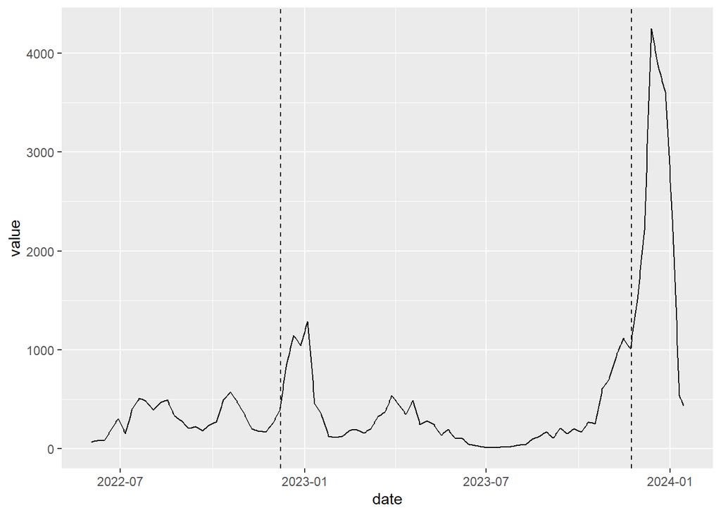

```r
Rt_one_1 = ymd("2022-12-22")
Rt_one_2 = ymd("2023-12-15")

df_transmission %>% filter(date>"2022-06-01",date<"2024-02-03") %>%  ggplot(aes(x=date,y=value))+
  geom_line() +
  geom_vline(xintercept = ymd(c("2022-12-08","2023-11-23")),linetype="dashed")
```

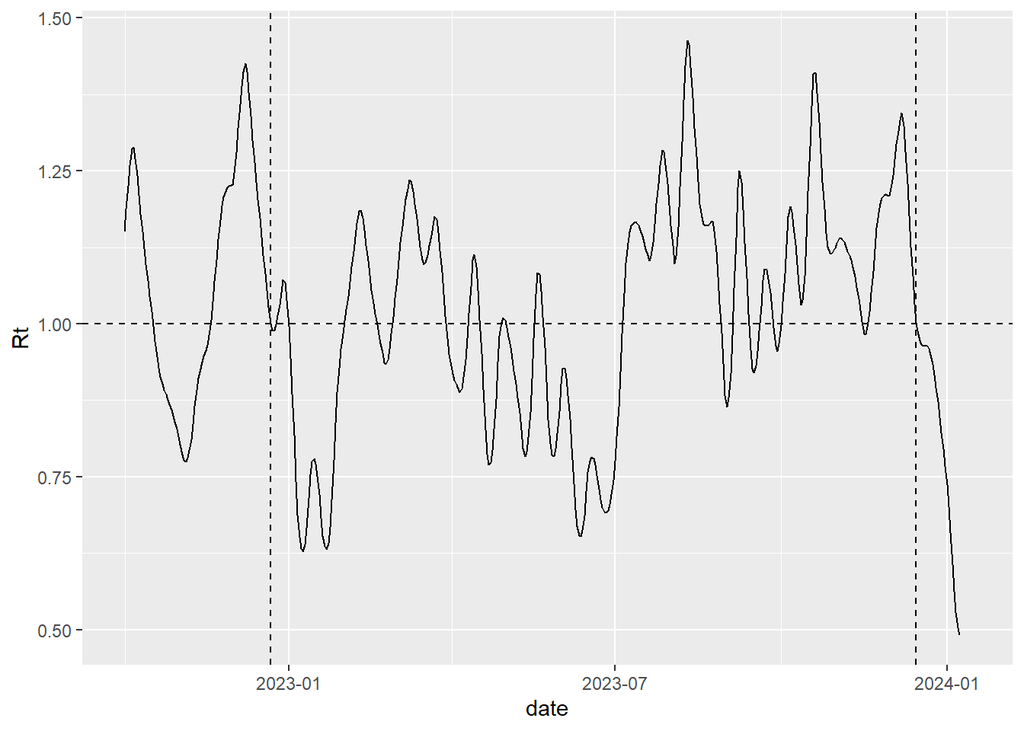

```r
df_transmission %>% filter(date>"2022-10-01",date<"2024-02-03") %>% ggplot(aes(x=date,y=Rt))+
  geom_line() +
  geom_hline(yintercept = 1,linetype="dashed")+
  geom_vline(xintercept = c(Rt_one_1,Rt_one_2),linetype="dashed")
```

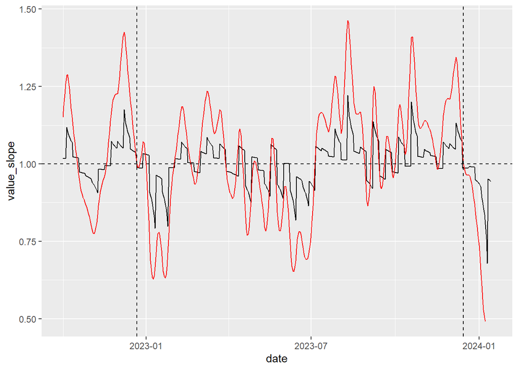

```r
df_transmission %>% filter(date>"2022-10-01",date<"2024-02-03") %>% ggplot()+
  geom_line(aes(x=date,
                y=value_slope ) ) +
  geom_line(aes(x=date,
                y=Rt ),col="red" ) +
  geom_hline(yintercept = 1,linetype="dashed")+
  geom_vline(xintercept = c(Rt_one_1,Rt_one_2),linetype="dashed")
```

### 1.3.3 *Modelling immunity against transmission and obtain augmented Rt*

```r
# add poplation sizes
df_all = df_transmission %>% left_join(aux$pops %>% select(location,location_name,population),by = join_by(location))
transmission_focus_dates = (df_all$date) %>% range()

df_all$Rt_at_one = 0
df_all$Rt_at_one[df_all$date == Rt_one_1] = 1
df_all$Rt_at_one[df_all$date == Rt_one_2] = 2

df_all$date[df_all$Rt_at_one!=0]
```

```
## [1] "2022-12-22" "2023-12-15"
```

```r
# df should start when Rt ~ 1
df_Rt_value_pop = df_all %>% filter_log(date>=Rt_one_1)
not_too_short_or_long(df_Rt_value_pop)
```

```
## df_Rt_value_pop has a good length :-)
```

```r
# optimising immunity_boe function
days_to_week=get_weekly_daygroups(df_Rt_value_pop)

f = function(...) compute_Rt_without_immunity(...,
                                              df_Rt_value_pop=df_Rt_value_pop,
                                              for_optim = T,
                                              p=p,days_to_week=days_to_week)
grid_i = 1
df_grid = list()
n_grid = 20
n_grid^4
```

```
## [1] 160000
```

```r
###############
# rule of thumb: something that increases with X% each week, takes 72/X weeks to double
if (T) { # 4 mins
  tic()
  for (NE_and_dark_factor_i in seq(from=log(20),to=log(200),length.out=30) ) {
    for ( wane_imm_fract_weekly_1_log_i in seq(from=logit(0.20),to=logit(0.20),length.out=1) ) {
      for ( Imm_2_partial_i in seq(from=logit(0.1),to=logit(0.5),length.out=40) ) {
        for ( wane_imm_fract_weekly_2_log_i in seq(from=logit(0.01),to=logit(0.01),length.out=1) ) {

          #######################################
          target_i = f( par=c(NE_and_dark_factor_i,
                              wane_imm_fract_weekly_1_log_i,
                              Imm_2_partial_i,
                              wane_imm_fract_weekly_2_log_i)
          )
          df_grid[[grid_i]] = tibble(NE_and_dark_factor=NE_and_dark_factor_i,
                                     wane_imm_fract_weekly_1_log=wane_imm_fract_weekly_1_log_i,
                                     Imm_2_partial = Imm_2_partial_i,
                                     wane_imm_fract_weekly_2_log=wane_imm_fract_weekly_2_log_i,
                                     target=target_i)
          grid_i = grid_i + 1
          #########################################
        }

      }
    }
  }
  toc()
}
```

[output not shown]

[output cut: 211 more lines]

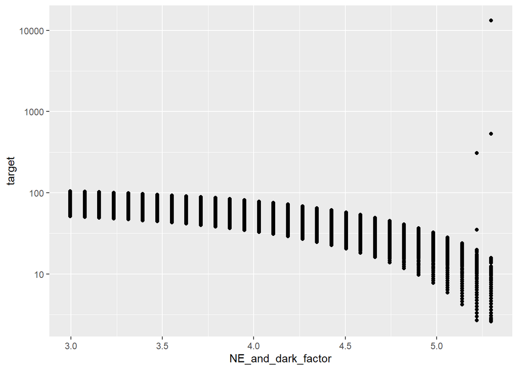

```r
#################
df_grid_all = bind_rows(df_grid)
df_grid_all %>% ggplot(aes(x=NE_and_dark_factor,y=target)) + geom_point() + scale_y_log10()
```

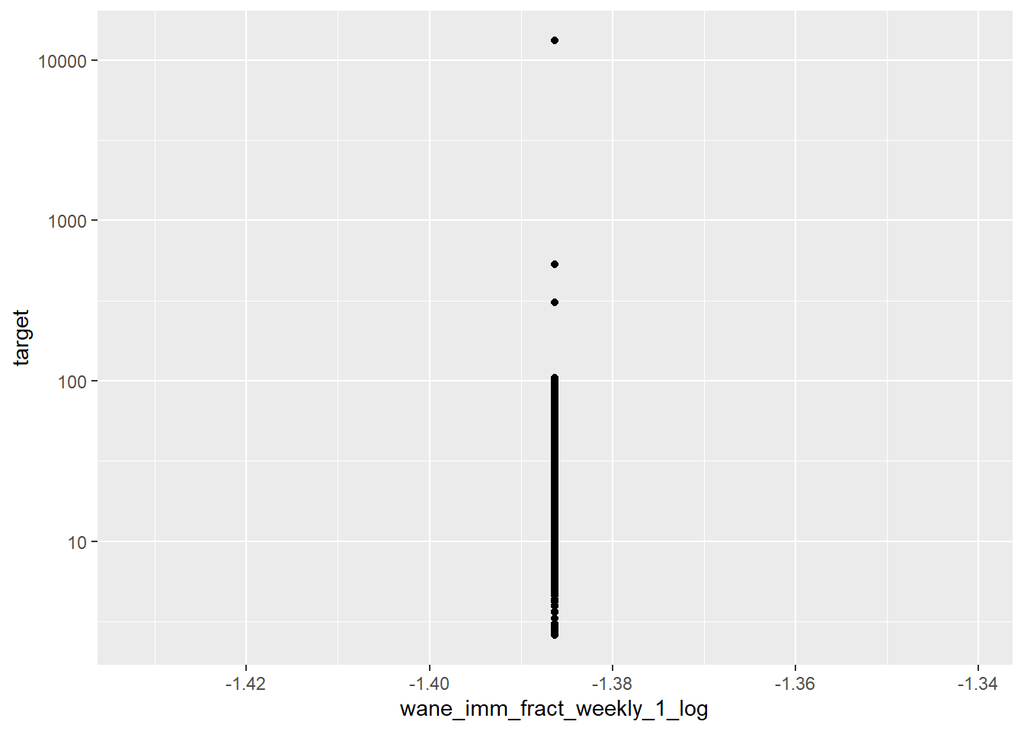

```r
df_grid_all %>% ggplot(aes(x=wane_imm_fract_weekly_1_log,y=target)) + geom_point()+ scale_y_log10()
```

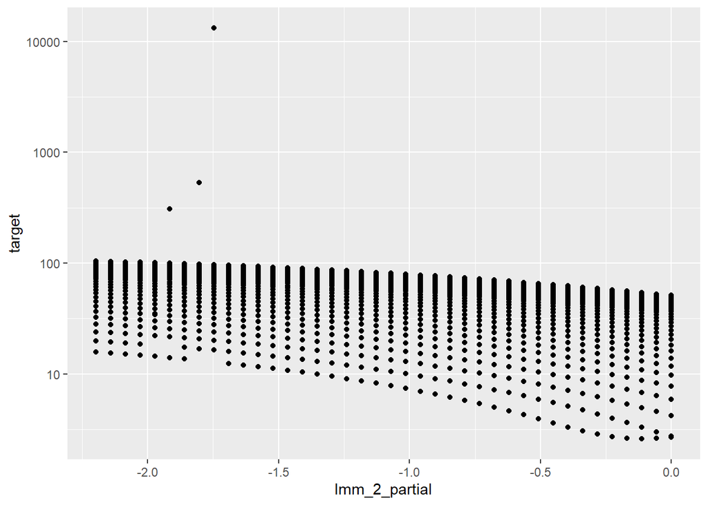

```r
df_grid_all %>% ggplot(aes(x=Imm_2_partial,y=target)) + geom_point()+ scale_y_log10()
```

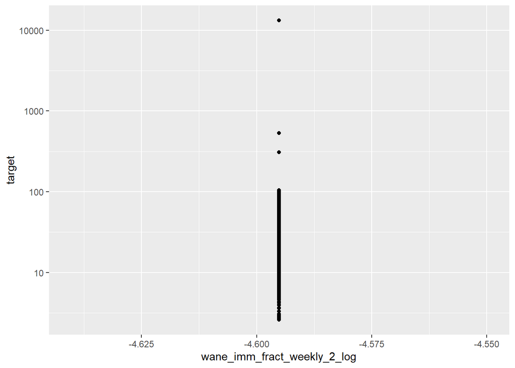

```r
df_grid_all %>% ggplot(aes(x=wane_imm_fract_weekly_2_log,y=target)) + geom_point()+ scale_y_log10()
```

```r
df_min = df_grid_all %>% filter(target==min(target))
df_Rt_without_imm = compute_Rt_without_immunity(par=c(df_min$NE_and_dark_factor,
                                                      df_min$wane_imm_fract_weekly_1_log,
                                                      df_min$Imm_2_partial,
                                                      df_min$wane_imm_fract_weekly_2_log) ,
                                                df_Rt_value_pop=df_Rt_value_pop ,
                                                for_optim=F,
                                                p=p,days_to_week=days_to_week)

par_min = c(df_min$NE_and_dark_factor,
            df_min$wane_imm_fract_weekly_1_log,
            df_min$Imm_2_partial,
            df_min$wane_imm_fract_weekly_2_log)

par_min %>% unscale_pars() %>% round(2)
```

```
## [1] 200.00   0.20   0.47   0.01
```

```r
df_Rt_without_imm = compute_Rt_without_immunity(par_min,
                                                df_Rt_value_pop=df_Rt_value_pop,
                                                for_optim = F,
                                                p=p,days_to_week=days_to_week)

# 120.30   0.15   0.40   0.00
```

```r
par_optim = par_min
if (F){
  f = function(...) compute_Rt_without_immunity(...,
                                                wane_imm_fract_weekly_1_log = par_min[2], # fix
                                                Imm_2_partial=par_min[3], # fix
                                                wane_imm_fract_weekly_2_log = par_min[4], # fix
                                                df_Rt_value_pop=df_Rt_value_pop,
                                                for_optim = T,
                                                p=p,days_to_week=days_to_week)
  res_optim = optim(par=par_min[1],fn=f)

  # previously:
  par_min %>% unscale_pars() %>% round(2)
  res_optim$par %>% unscale_pars() %>% round(2)

  df_Rt_without_imm = compute_Rt_without_immunity(par=res_optim$par,
                                                  Imm_2_partial=par_min[3], # fix
                                                  wane_imm_fract_weekly_2_log = par_min[4], # fix
                                                  df_Rt_value_pop,
                                                  for_optim = F,
                                                  p=p,days_to_week=days_to_week)
}
```

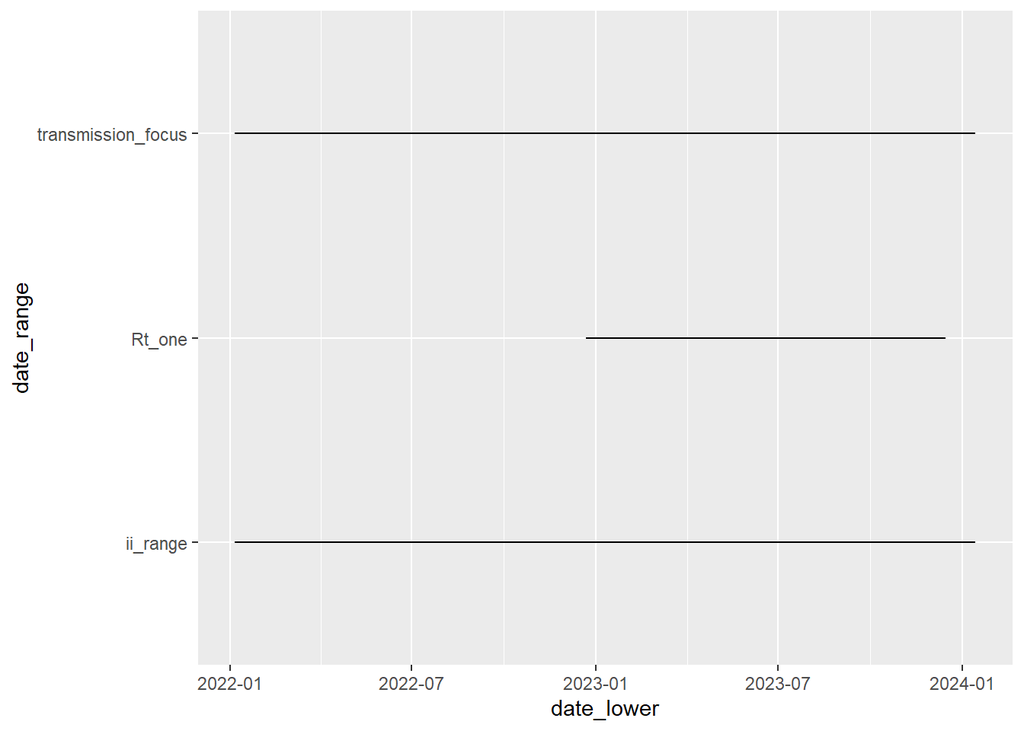

```r
# look
date_start = "2022-11-12"

tibble(
  date_range=c("ii_range","transmission_focus","Rt_one"),
  date_lower=c(range_df_ii[1],transmission_focus_dates[1],Rt_one_1),
  date_upper=c(range_df_ii[2],transmission_focus_dates[2],Rt_one_2)) %>%
  ggplot(aes(y=date_range,yend=date_range)) +
  geom_segment(aes(x=date_lower,xend=date_upper))
```

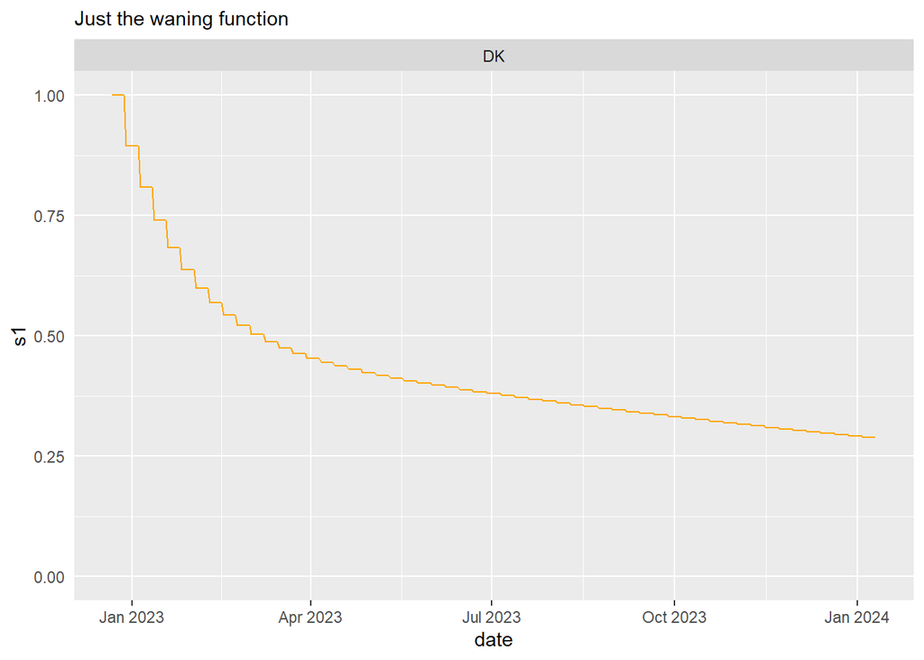

```r
df_Rt_without_imm %>%
  filter(date>date_start) %>%
  ggplot(aes(x=date)) +
  geom_line(aes(y=s1),col="orange") +
  facet_wrap(~location,scales="free_y") + coord_cartesian(ylim=c(0,1)) +
  theme(axis.ticks.y=element_blank()) + labs(subtitle = "Just the waning function")
```

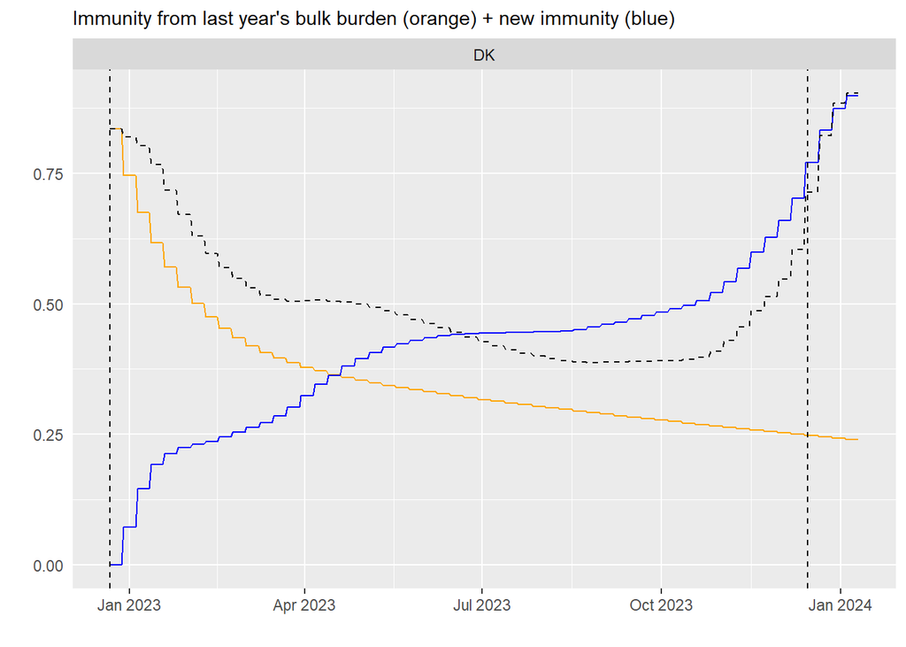

```r
df_Rt_without_imm %>%
  filter(date>date_start) %>%
  ggplot(aes(x=date)) +
  geom_line(aes(y=s3),col="orange") +
  geom_line(aes(y=1-1/s2),col="blue") +
  geom_line(aes(y=Imm),col="black",linetype="dashed") +
  geom_vline(xintercept = c(Rt_one_1,Rt_one_2),linetype="dashed") +
  facet_wrap(~location,scales="free_y") +
  theme(axis.ticks.y=element_blank()) +
  labs(y="",x="",subtitle = "Immunity from last year's bulk burden (orange) + new immunity (blue)")
```

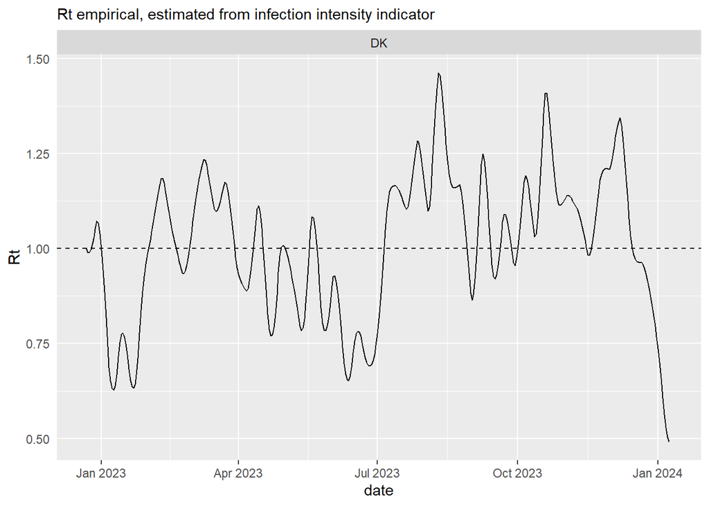

```r
df_Rt_without_imm %>%
  filter(date>date_start) %>%
  ggplot(aes(x=date)) +
  geom_line(aes(y=Rt),col="black") +
  geom_hline(yintercept = 1,linetype="dashed") + facet_wrap(~location,scales="free_y") +
  theme(axis.ticks.y=element_blank()) + labs(subtitle = "Rt empirical, estimated from infection intensity indicator")
```

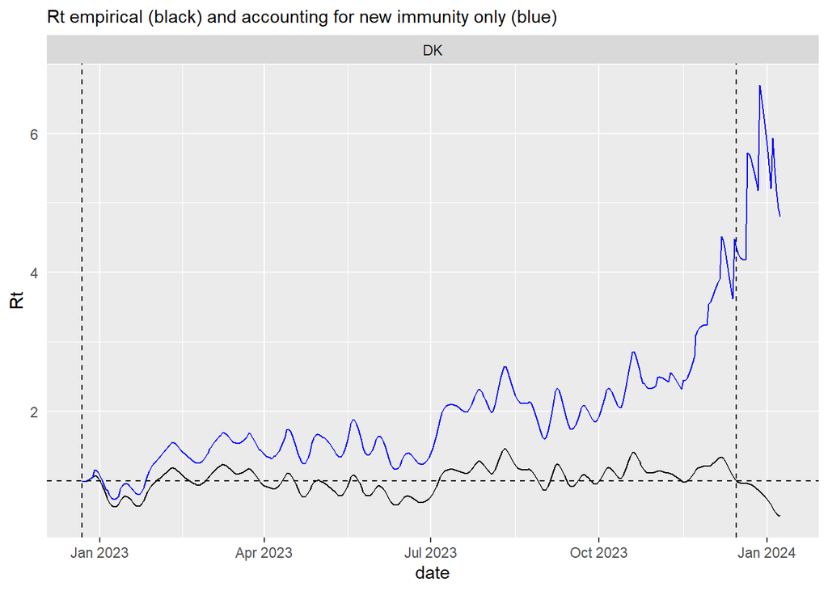

```r
df_Rt_without_imm %>%
  filter(date>date_start) %>%
  ggplot(aes(x=date)) +
  geom_line(aes(y=Rt),col="black") +
  geom_line(aes(y=s2*Rt),col="blue") +
  geom_vline(xintercept = c(Rt_one_1,Rt_one_2),linetype="dashed")+
  geom_hline(yintercept = 1,linetype="dashed") + facet_wrap(~location,scales="free_y") +
  theme(axis.ticks.y=element_blank()) + labs(subtitle = "Rt empirical (black) and accounting for new immunity only (blue)")
```

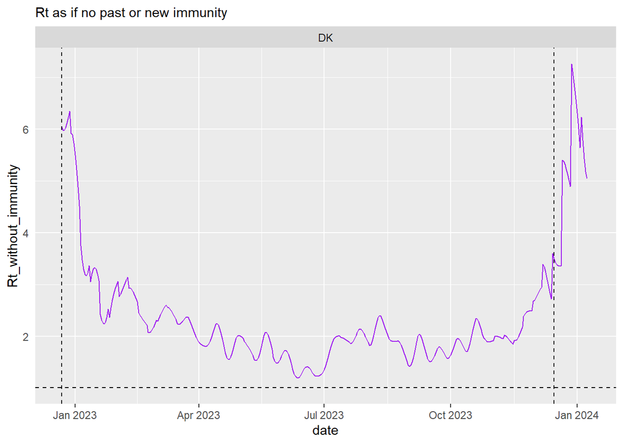

```r
df_Rt_without_imm %>%
  filter(date>date_start) %>%
  ggplot(aes(x=date)) +
  geom_line(aes(y=Rt_without_immunity),col="purple") +
  geom_vline(xintercept = c(Rt_one_1,Rt_one_2),linetype="dashed")+
  geom_hline(yintercept = 1,linetype="dashed") + facet_wrap(~location,scales="free_y") +
  theme(axis.ticks.y=element_blank()) + labs(subtitle = "Rt as if no past or new immunity")
```

```r
df_Rt_without_imm$Rt_without_immunity
```

[output not shown]

[output cut: 34 more lines]